# Fantasy Scores

# Libraries

Not all of the functions are available in base `R`. So, we’ll have to load some extra functions in order to work with our data.

```r
library(corrplot)
library(skimr)
library(tidyverse)
```

If you cannot load these libraries with this code, then this means you haven’t installed those libraries. In `R`, you need to install libraries before you use them. To install a library, you use

```r
install.packages(c("tidverse", "skimr", "corrplot"), dep = TRUE)
```

# Load Data

There are data files for each key position in fantasy football: QB, RB, WR, K, and D/ST. Here, we’ll read in each file:

```r
qbs <- readRDS("../data/fantasy/fantasy_projections_2018_nfl_QB.Rds")
rbs <- readRDS("../data/fantasy/fantasy_projections_2018_nfl_RB.Rds")
wrs <- readRDS("../data/fantasy/fantasy_projections_2018_nfl_WR.Rds")
kick <- readRDS("../data/fantasy/fantasy_projections_2018_nfl_K.Rds")
dst <- readRDS("../data/fantasy/fantasy_projections_2018_nfl_DST.Rds")
```

Note that depending on where your `R` script is located, you’ll have to change part of the code above so that it corresponds with how you’ve organized your files (i.e., you give the functions the correct paths).

Now we have five data frames, each with their own sets of variables.

The data were scraped from NFL.com. Each table has information on player fantasy stats by week for the 2018 season. For a given player and week, it contains information on the points that NFL.com projected for them, how many points they actually got, and how they got those points (e.g., how many TDs and yards they had).

# Inspect Data

```r
head(rbs)
```

```
## # A tibble: 6 x 23
##   data_src id    src_id  esbid gsisplayerid player   pos   team  seasonpts
##   <chr>    <chr> <chr>   <chr> <chr>        <chr>    <chr> <chr>     <dbl>
## 1 NFL      12155 2552374 ABD6… 00-0032104   Ameer A… RB    MIN         0.9
## 2 NFL      12154 2552582 AJA7… 00-0031590   Jay Aja… RB    PHI        38.4
## 3 NFL      12159 2552631 ALL4… 00-0031577   Javoriu… RB    BAL        58.6
## 4 NFL      11454 2540269 AND1… 00-0029854   C.J. An… RB    LA         62.4
## 5 NFL      13326 2558833 ARM0… 00-0033296   Alex Ar… RB    CAR        14
## 6 NFL      12161 2552375 ART3… 00-0031599   Cameron… RB    CAR        14.4
## # ... with 14 more variables: site_season_pts <dbl>, weekpts <dbl>,
## #   site_pts <dbl>, games <dbl>, rush_yds <dbl>, rush_tds <dbl>,
## #   rec <dbl>, rec_yds <dbl>, rec_tds <dbl>, ret_tds <dbl>,
## #   fumbles_lost <dbl>, two_pts <dbl>, week <int>, season <dbl>
```

Note that there is a column called `weekpts` which shows how many points a player got in a given week. There’s also something called `site_pts` which shows how many points NFL.com projected them to have.

Take some time to look through these rows and make sure you understand all of the variables in it.

Note that for some of the stats (`rec_td` or `rush_td`), when the value should be zero, it is instead reported as missing (in `R`, this is denoted `NA`). This means we need to replace some of those “missing” values in the data with 0:

```r
rbs <- rbs %>%
  mutate_if(.predicate = function(field) is.numeric(field) & anyNA(field),
            .funs = function(x) ifelse(is.na(x), 0, x))
```

## Summarizing the Data

The `skimr` library, which we loaded above, has a nice function `skim()` gives a nice ordered summary of your data, including univariate summary statistics and histograms:

```r
rbs %>% skim()
```

```
## Skim summary statistics
##  n obs: 1642
##  n variables: 23
##
## ── Variable type:character ───────────────────────────────────────────────────────────────
##      variable missing complete    n min max empty n_unique
##      data_src       0     1642 1642   3   3     0        1
##         esbid       0     1642 1642   9   9     0      161
##  gsisplayerid       0     1642 1642  10  10     0      161
##            id       6     1636 1642   4   5     0      159
##        player       0     1642 1642   8  23     0      161
##           pos       0     1642 1642   2   2     0        1
##        src_id       0     1642 1642   3   7     0      161
##          team       0     1642 1642   0   3    24       33
##
## ── Variable type:integer ─────────────────────────────────────────────────────────────────
##  variable missing complete    n mean   sd p0 p25 p50 p75 p100     hist
##      week       0     1642 1642  8.4 4.76  1   4   8  13   16 ▇▇▇▆▆▆▇▇
##
## ── Variable type:numeric ─────────────────────────────────────────────────────────────────
##         variable missing complete    n      mean     sd      p0     p25
##     fumbles_lost       0     1642 1642    0.034   0.045    0       0
##            games       0     1642 1642    1       0        1       1
##              rec       0     1642 1642    1.55    1.37     0       0.47
##          rec_tds       0     1642 1642    0.07    0.073    0       0.02
##          rec_yds       0     1642 1642   13.27   12.44     0       3.7
##          ret_tds       0     1642 1642    0.0053  0.028    0       0
##         rush_tds       0     1642 1642    0.19    0.19     0       0.03
##         rush_yds       0     1642 1642   27.27   26.36     0       4.31
##           season       0     1642 1642 2018       0     2018    2018
##        seasonpts       0     1642 1642   76.78   75       -0.7    11.8
##         site_pts       0     1642 1642    5.55    4.93     0.03    1.17
##  site_season_pts       0     1642 1642   63.3    74.62     0       1.73
##          two_pts       0     1642 1642    0.006   0.014    0       0
##          weekpts       0     1642 1642    5.53    7.2     -1.6     0
##      p50     p75    p100     hist
##     0.02    0.05    0.28 ▇▂▁▁▁▁▁▁
##     1       1       1    ▁▁▁▇▁▁▁▁
##     1.06    2.3     7.66 ▇▃▂▁▁▁▁▁
##     0.04    0.09    0.43 ▇▂▂▁▁▁▁▁
##     8.9    19.68   70.77 ▇▃▂▁▁▁▁▁
##     0       0       0.32 ▇▁▁▁▁▁▁▁
##     0.11    0.32    0.85 ▇▂▂▂▂▁▁▁
##    17.15   50.89  101.1  ▇▃▂▁▂▂▁▁
##  2018    2018    2018    ▁▁▁▇▁▁▁▁
##    59     118.1   313.1  ▇▃▃▂▂▁▁▁
##     4.02    9.25   21.52 ▇▃▂▂▂▁▁▁
##    37.71   97.99  291.56 ▇▂▂▁▁▁▁▁
##     0       0.01    0.1  ▇▁▁▁▁▁▁▁
##     2.5     8.7    47.8  ▇▂▂▁▁▁▁▁
```

Note that in our syntax above, we used the pipe `%>%` command. This has the effect of saying take the object before the pipe (in this case, the `rbs` data frame) and feed it into the function after the pipe (`skim()`). You could get the same effect as the code above by running `skim(rbs)`.

While univariate summaries are important, we’re also interested in the relationship between variables. One way to examine that relationship is with the correlation between them. Correlation ranges between -1 and 1. Correlations close to -1 means that two variables are closely related, but that the larger one gets, the smaller the other gets. Correlations close to 0 means that the two variables are potentially unrelated. Correlations close to 1 means that to variables are closely related, and larger values of one variable are associated with larger values of the other.

We can get a plot of some important pairwise correlations in our data with the following code:

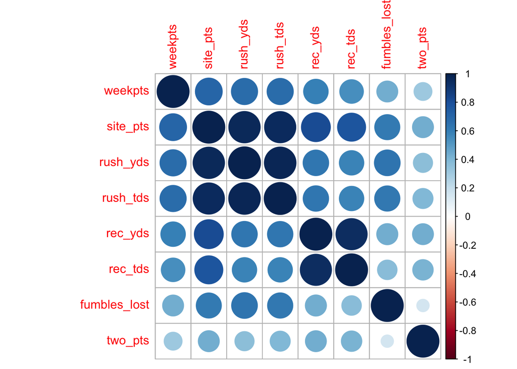

```r
rbs %>%
  select(weekpts, site_pts, rush_yds, rush_tds, rec_yds, rec_tds, fumbles_lost, two_pts) %>%
  cor(.) %>%
  corrplot()
```

Not surprisingly, things like the yards and TDs are associated with higher fantasy points.

## Other Visualization

Finally, not all relationships are captured by the correlation between variables. Particularly if relationships are not linear, sometimes the correlation between variables can be zero, even if they are closely related.

Thus, we might want to get other visualizations. To do that, we can use the `ggplot` library. This library treats your plot like a canvas. You start by saying what data you want to visualize, and then continually add layers to the plot. For example, in the code below, we say we want to visualize the RB data (first line), and that we want to add points that correspond to the projected and actual points:

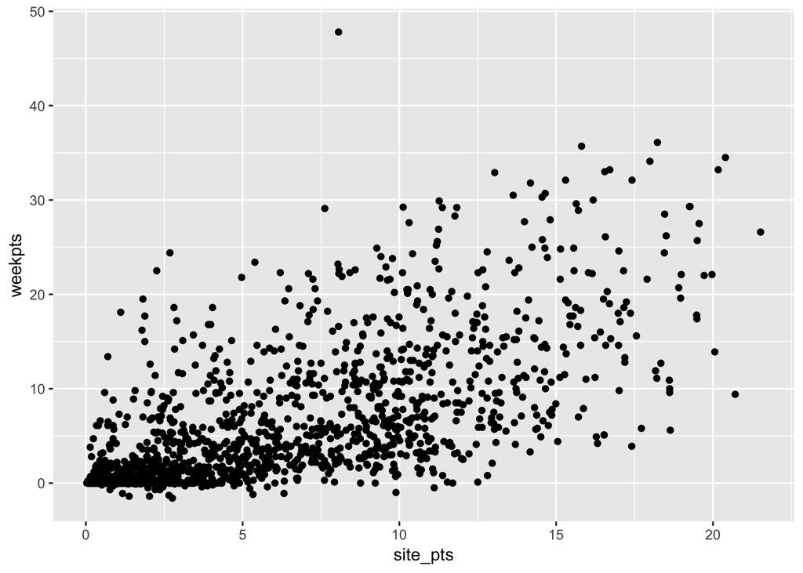

```r
ggplot(rbs) +
  geom_point(aes(site_pts, weekpts)) # make sure the variable names are inside the aes() function
```

Suppose we want to add some reference lines to this plot. First, we would think that really good projections should be pretty close to the actual points. Therefore, these points (if the projections are good) should be pretty close to the line `y = x`. We can add that line to this plot pretty easily (with `stat_function()` in the code below). We might also want to see what a smoothed average function (called a LOESS) that “learns” how to predict actual fantasy points from the projected points looks like. The following code does both:

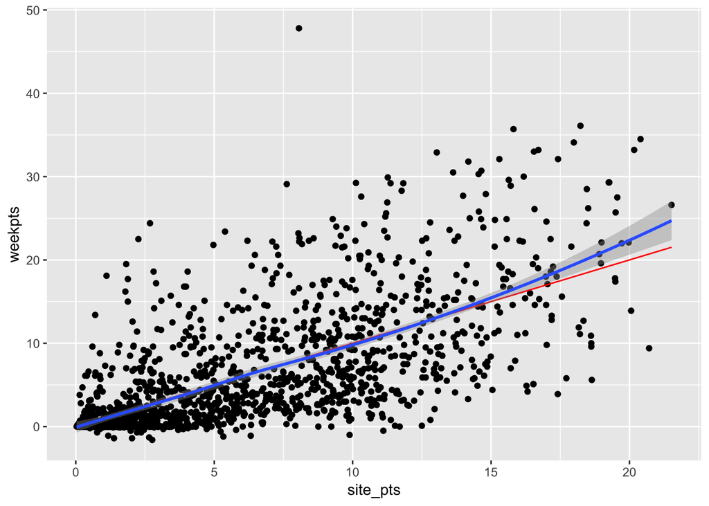

```r
ggplot(rbs) + # start canvas with rb data
  geom_point(aes(site_pts, weekpts)) + # add the points
  stat_function(fun = function(x) x, color = 'red') + # plot line y = x in red
  geom_smooth(aes(site_pts, weekpts), method = "loess") # add the smoothed loess curve
```

We see that the smoothed “learned” LOESS curve looks pretty close to the `y = x` line for much of the data, but seems to be higher than it further out on the $x$-axis. Moreover, there is a lot of variation in predictions around the `y = x` line.

# Your Turn

Use the code above to do the following:

1. Create more visualizations for the RBs dataset.
2. Repeat for the QB, WR, D/ST, and K datasets.

Try to embed everything in Rmarkdown (i.e., the template document). We’ll look at how to add code chunks during the meeting.

If you get lost, a handy reference is the free e-book [R for Data Science](https://r4ds.had.co.nz/)